# Credit Card Fraud Detection

## About the data

The data that has been used as part of this project is from kaggle. Quoting from kaggle, “The datasets contains transactions made by credit cards in September 2013 by european cardholders. This dataset presents transactions that occurred in two days, where we have 492 frauds out of 284,807 transactions. The dataset is highly unbalanced, the positive class (frauds) account for 0.172% of all transactions.

It contains only numerical input variables which are the result of a PCA transformation. Unfortunately, due to confidentiality issues, we cannot provide the original features and more background information about the data. Features V1, V2, … V28 are the principal components obtained with PCA, the only features which have not been transformed with PCA are ‘Time’ and ‘Amount’. Feature ‘Time’ contains the seconds elapsed between each transaction and the first transaction in the dataset. The feature ‘Amount’ is the transaction Amount, this feature can be used for example-dependant cost-senstive learning. Feature ‘Class’ is the response variable and it takes value 1 in case of fraud and 0 otherwise.

Given the class imbalance ratio, we recommend measuring the accuracy using the Area Under the Precision-Recall Curve (AUPRC). Confusion matrix accuracy is not meaningful for unbalanced classification.

The dataset has been collected and analysed during a research collaboration of Worldline and the Machine Learning Group (http://mlg.ulb.ac.be) of ULB (Université Libre de Bruxelles) on big data mining and fraud detection. More details on current and past projects on related topics are available on http://mlg.ulb.ac.be/BruFence and http://mlg.ulb.ac.be/ARTML

Please cite: Andrea Dal Pozzolo, Olivier Caelen, Reid A. Johnson and Gianluca Bontempi. Calibrating Probability with Undersampling for Unbalanced Classification. In Symposium on Computational Intelligence and Data Mining (CIDM), IEEE, 2015 "

```r
ccfraud <- read.csv('creditcard.csv')
ccfraud$Class <- as.factor(ccfraud$Class)
levels(ccfraud$Class) <- c("Geniune", "Fraud")

dim(ccfraud)
```

```
## [1] 284807     31
```

```r
ftable(ccfraud$Class)
```

```
##  Geniune  Fraud
##
##   284315    492
```

```r
library(VIM)
library(Amelia)
#missmap(ccfraud)  - Takes too long
```

```r
data(ccfraud, package = "VIM")
## Show incomplete cases
sleep[!complete.cases(ccfraud),]
```

```
##  [1] BodyWgt  BrainWgt NonD     Dream    Sleep    Span     Gest
##  [8] Pred     Exp      Danger
## <0 rows> (or 0-length row.names)
```

```r
library(mice)
#md.pattern(ccfraud)
```

There are no missing data in the dataset. ## Plots on each of the variables

```r
cn <- colnames(ccfraud[,1:30])
print(cn)
```

```
##  [1] "Time"   "V1"     "V2"     "V3"     "V4"     "V5"     "V6"
##  [8] "V7"     "V8"     "V9"     "V10"    "V11"    "V12"    "V13"
## [15] "V14"    "V15"    "V16"    "V17"    "V18"    "V19"    "V20"
## [22] "V21"    "V22"    "V23"    "V24"    "V25"    "V26"    "V27"
## [29] "V28"    "Amount"
```

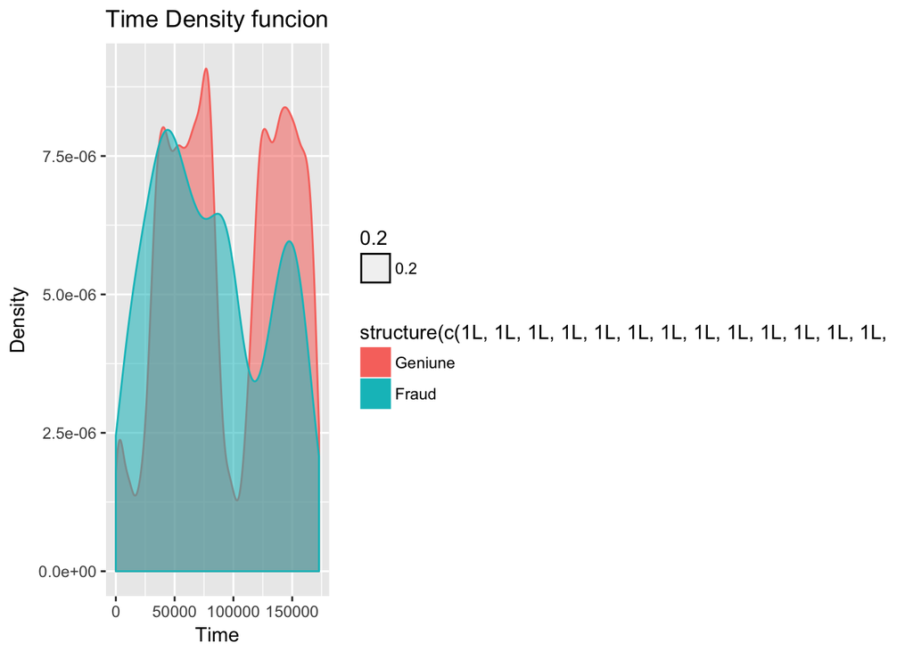

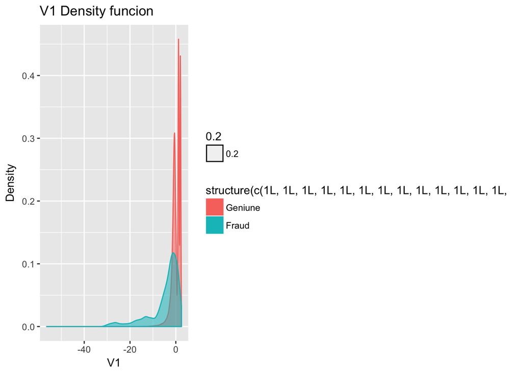

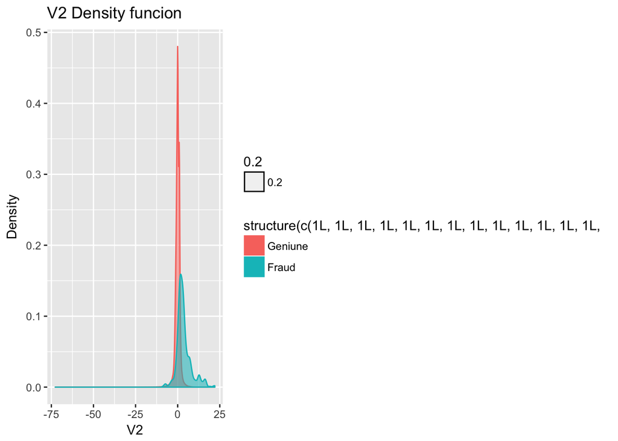

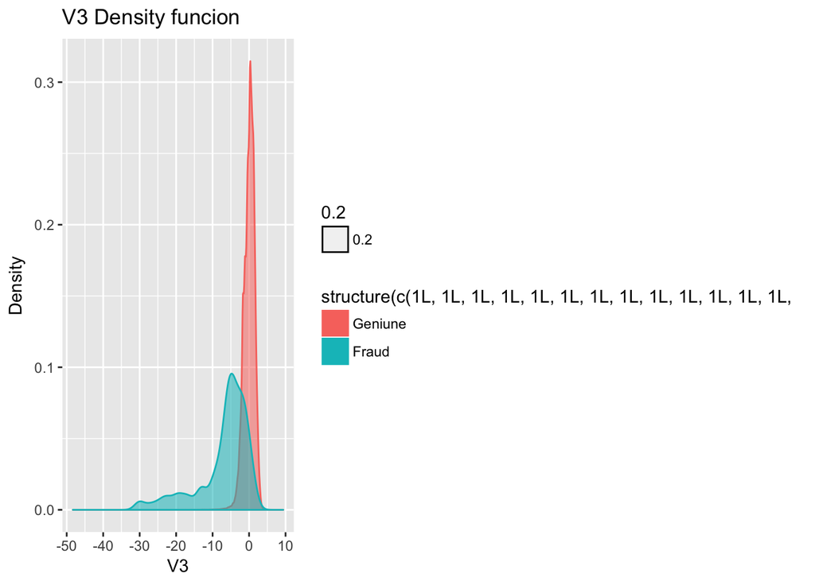

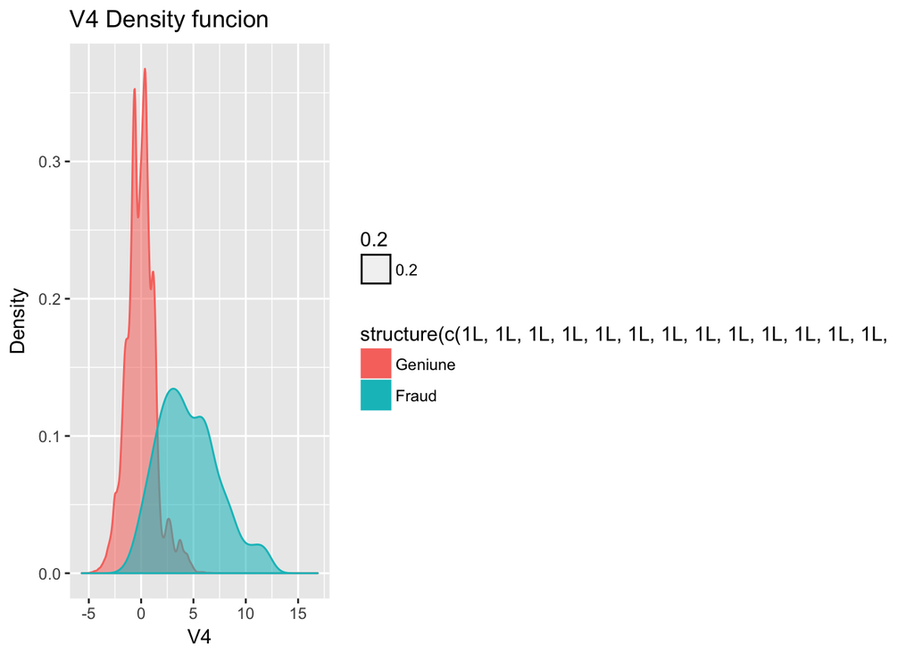

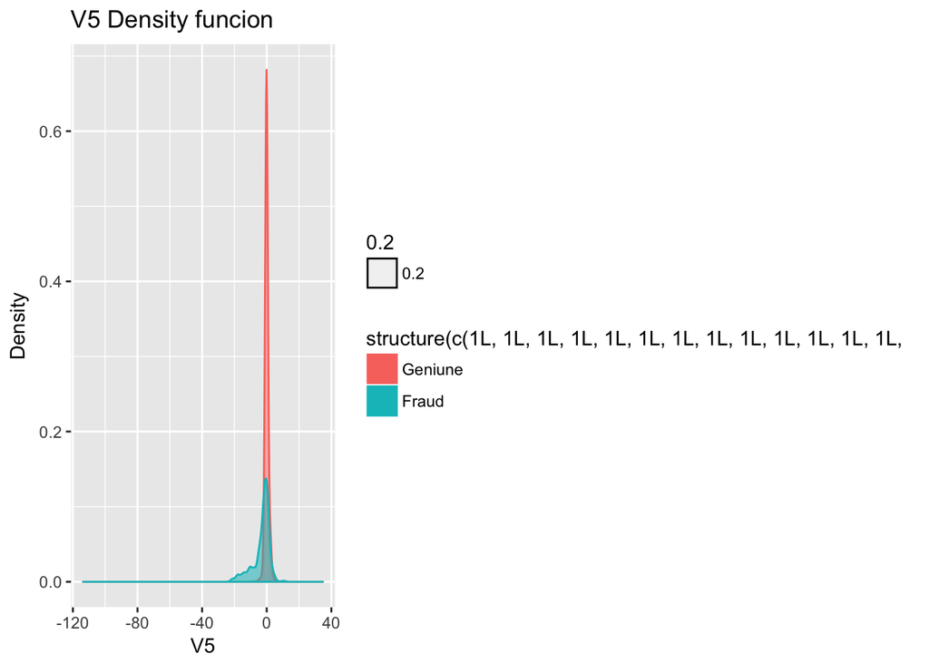

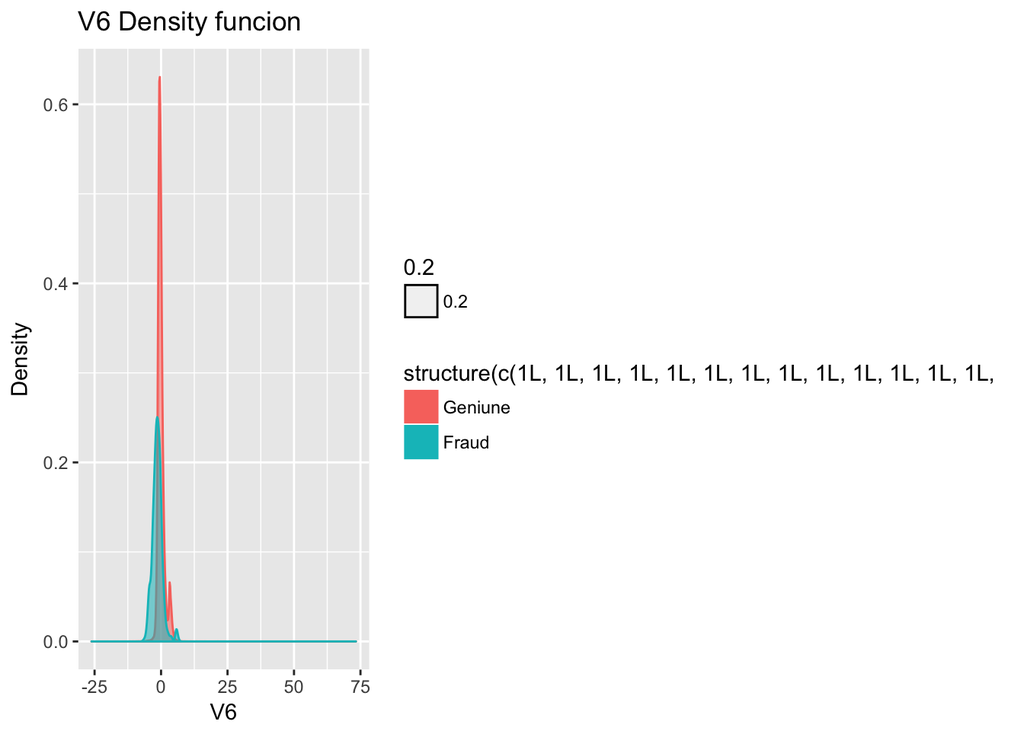

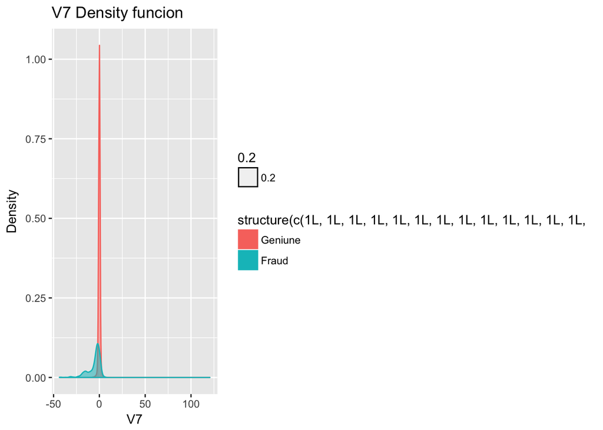

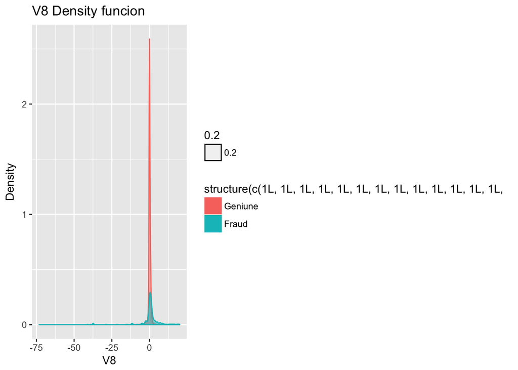

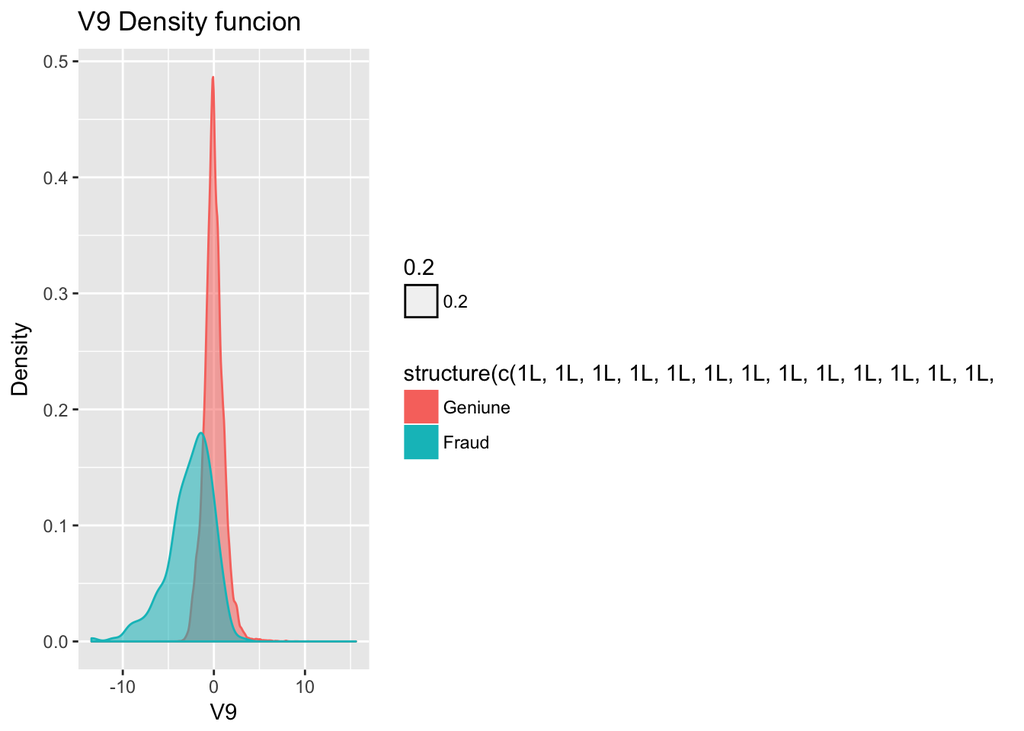

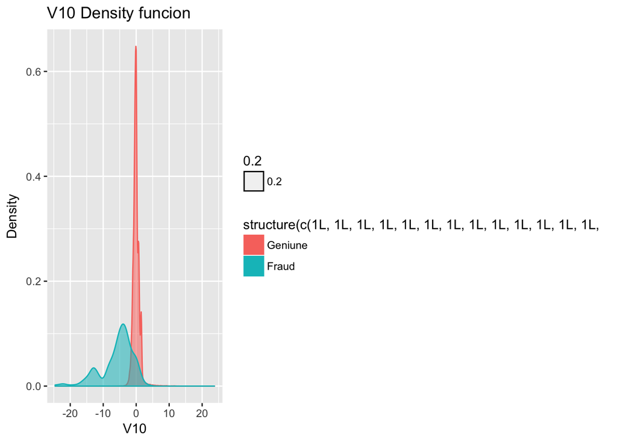

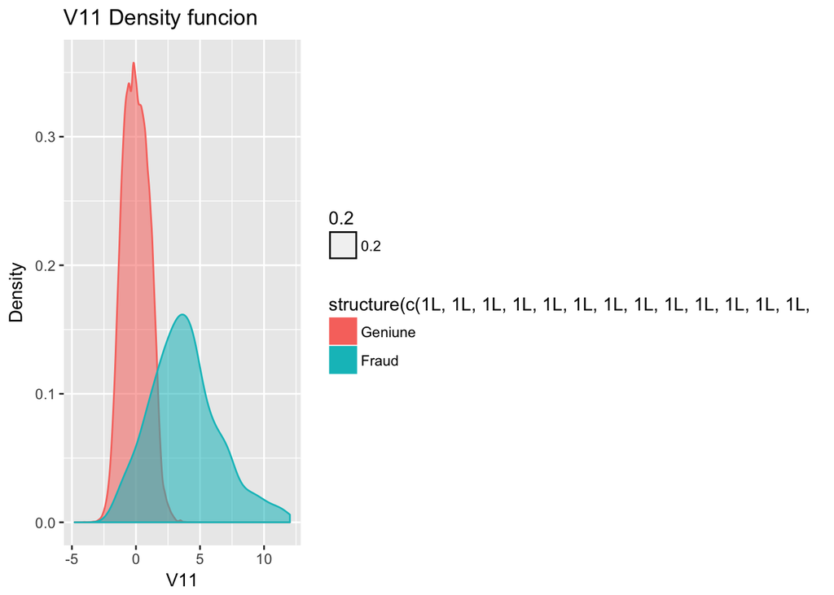

[18 more figures not shown]

```r
vars = paste("V", 1:30, sep="")
par(mfrow=c(29,4))
library(ggplot2)
for( var in cn){
   p <- ggplot(ccfraud, aes_string(x =  var,
               fill = ccfraud$Class, colour = ccfraud$Class, alpha = 0.2)) +
               geom_density() + xlab(paste(var)) +
               ylab("Density") +
               ggtitle(paste(var, "Density funcion"))
   print(p)
}
```

## Correlation Plot This is not really important here as input data is already a PCA tranformation.

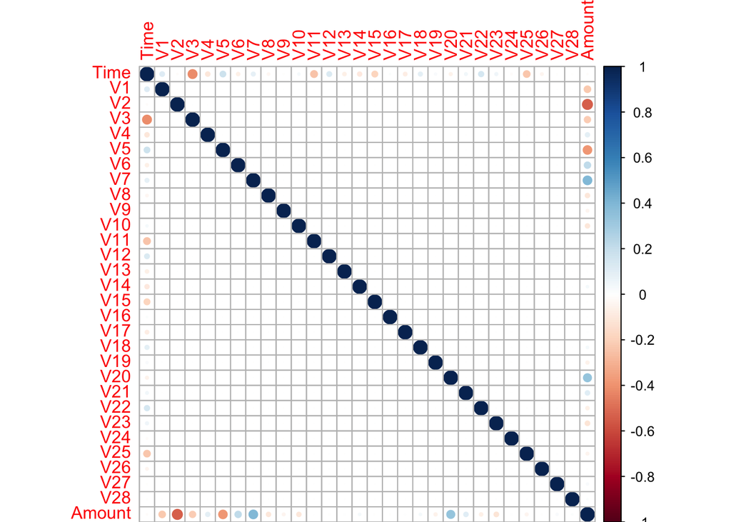

```r
library(corrplot)
cp <- corrplot(cor(ccfraud[, 1:30]))
```

```r
print(cp)
```

```
##                Time            V1            V2            V3
## Time    1.000000000  1.173963e-01 -1.059333e-02 -4.196182e-01
## V1      0.117396306  1.000000e+00 -6.965284e-17 -5.689257e-16
## V2     -0.010593327 -6.965284e-17  1.000000e+00  5.207402e-17
## V3     -0.419618172 -5.689257e-16  5.207402e-17  1.000000e+00
## V4     -0.105260205 -2.602863e-16 -1.613213e-16 -2.229734e-16
## V5      0.173072123  3.146931e-16  1.119124e-16 -6.014871e-16
## V6     -0.063016470  1.492868e-16  3.870545e-16  1.427210e-15
## V7      0.084714375  7.841775e-17 -1.307637e-16  2.297393e-16
## V8     -0.036949435 -5.446145e-17 -2.461255e-17 -7.356493e-17
## V9     -0.008660434  3.813198e-17 -1.123192e-16  1.037123e-16
## V10     0.030616629  5.323676e-17 -1.342760e-16  2.047704e-16
## V11    -0.247689437  3.002286e-16  3.438822e-16  1.136658e-16
## V12     0.124348068  1.818542e-16 -3.249832e-16  2.105842e-16
## V13    -0.065902024 -4.924522e-17 -3.781395e-17 -3.519517e-17
## V14    -0.098756819  3.872776e-16 -3.806711e-16  6.698461e-16
## V15    -0.183453273 -9.135222e-17  6.457046e-17 -6.312482e-17
## V16     0.011902868  3.349857e-16  4.068406e-17  5.714038e-16
## V17    -0.073297213 -2.373744e-17 -6.403585e-16  9.221563e-17
## V18     0.090438133  1.468961e-16  2.334236e-16  3.128313e-16
## V19     0.028975303  1.649928e-16  1.202548e-17  3.456581e-16
## V20    -0.050866018  1.432581e-16  8.194049e-17  7.004887e-17
## V21     0.044735726 -9.271675e-17  8.039593e-17 -1.592155e-16
## V22     0.144059055  9.611336e-17  1.701033e-16 -2.257641e-16
## V23     0.051142365  1.757891e-16  1.346719e-16 -7.683090e-17
## V24    -0.016181868 -5.157132e-17 -1.071030e-16  2.526865e-17
## V25    -0.233082791 -2.390623e-16  1.157084e-16  1.145955e-16
## V26    -0.041407101 -1.264191e-16  2.620792e-16 -2.164134e-16
## V27    -0.005134591  9.657711e-17 -5.267197e-16  5.247791e-16
## V28    -0.009412688  3.679910e-16 -3.781747e-16  7.328569e-16
## Amount -0.010596373 -2.277087e-01 -5.314089e-01 -2.108805e-01
##                   V4            V5            V6            V7
## Time   -1.052602e-01  1.730721e-01 -6.301647e-02  8.471437e-02
## V1     -2.602863e-16  3.146931e-16  1.492868e-16  7.841775e-17
## V2     -1.613213e-16  1.119124e-16  3.870545e-16 -1.307637e-16
## V3     -2.229734e-16 -6.014871e-16  1.427210e-15  2.297393e-16
## V4      1.000000e+00 -1.841492e-15 -4.247485e-16 -7.423988e-17
## V5     -1.841492e-15  1.000000e+00  6.266854e-16 -2.011798e-17
## V6     -4.247485e-16  6.266854e-16  1.000000e+00 -4.980567e-17
## V7     -7.423988e-17 -2.011798e-17 -4.980567e-17  1.000000e+00
```

[output cut: 193 more lines]

```
## V15    -1.121411e-15 -0.002985848
## V16     7.028481e-16 -0.003909527
## V17    -8.344534e-17  0.007309042
## V18     8.010596e-16  0.035650341
## V19    -1.361453e-15 -0.056150787
## V20    -2.264586e-16  0.339403405
## V21     2.025134e-16  0.105998928
## V22    -5.377144e-16 -0.064800646
## V23     1.367329e-15 -0.112632554
## V24    -2.770212e-16  0.005146217
## V25     3.734279e-16 -0.047836863
## V26    -2.952380e-16 -0.003208037
## V27     3.001876e-17  0.028825463
## V28     1.000000e+00  0.010258216
## Amount  1.025822e-02  1.000000000
```

## Splitting Data for our train/test

```r
library(caret)
set.seed(123)

index <- createDataPartition(ccfraud$Class, p = 0.7, list = FALSE)
train_data <- ccfraud[index, ]
test_data  <- ccfraud[-index, ]
ftable(train_data$Class)
```

```
##  Geniune  Fraud
##
##   199021    345
```

```r
ftable(test_data$Class)
```

```
##  Geniune Fraud
##
##    85294   147
```

```r
MiscFactors <- c()
pcafactors <-paste("V", 1:28, sep="")
formula = reformulate(termlabels = c(MiscFactors,pcafactors), response = 'Class')
print (formula)
```

```
## Class ~ V1 + V2 + V3 + V4 + V5 + V6 + V7 + V8 + V9 + V10 + V11 +
##     V12 + V13 + V14 + V15 + V16 + V17 + V18 + V19 + V20 + V21 +
##     V22 + V23 + V24 + V25 + V26 + V27 + V28
```

```r
ControlParamteres <- trainControl(method = "cv",
                                  number = 10,
                                  savePredictions = TRUE,
                                  classProbs = TRUE,
                                  verboseIter = TRUE
)
str(train_data)
```

```
## 'data.frame':    199366 obs. of  31 variables:
##  $ Time  : num  0 0 1 1 2 2 4 7 7 10 ...
##  $ V1    : num  -1.36 1.192 -1.358 -0.966 -1.158 ...
##  $ V2    : num  -0.0728 0.2662 -1.3402 -0.1852 0.8777 ...
##  $ V3    : num  2.536 0.166 1.773 1.793 1.549 ...
##  $ V4    : num  1.378 0.448 0.38 -0.863 0.403 ...
##  $ V5    : num  -0.3383 0.06 -0.5032 -0.0103 -0.4072 ...
##  $ V6    : num  0.4624 -0.0824 1.8005 1.2472 0.0959 ...
##  $ V7    : num  0.2396 -0.0788 0.7915 0.2376 0.5929 ...
##  $ V8    : num  0.0987 0.0851 0.2477 0.3774 -0.2705 ...
##  $ V9    : num  0.364 -0.255 -1.515 -1.387 0.818 ...
##  $ V10   : num  0.0908 -0.167 0.2076 -0.055 0.7531 ...
##  $ V11   : num  -0.552 1.613 0.625 -0.226 -0.823 ...
##  $ V12   : num  -0.6178 1.0652 0.0661 0.1782 0.5382 ...
##  $ V13   : num  -0.991 0.489 0.717 0.508 1.346 ...
```

[output cut: 17 more lines]

```r
model.glm <- train(formula, data = train_data,method = "glm", family="binomial", trControl = ControlParamteres)
exp(coef(model.glm$finalModel))
```

```
##  (Intercept)           V1           V2           V3           V4
## 0.0001958784 1.0465226361 0.9692444177 1.0153588236 1.9545622788
##           V5           V6           V7           V8           V9
## 1.0040275509 0.8729683757 0.9622179694 0.8190839236 0.8090811225
##          V10          V11          V12          V13          V14
## 0.4658158788 1.0298687876 0.9696172856 0.7447382118 0.5935635399
##          V15          V16          V17          V18          V19
## 0.9115946086 0.8742182886 1.0436825514 0.9773124043 1.0100473879
##          V20          V21          V22          V23          V24
## 0.7444748231 1.4329545639 1.5347401880 0.8957445857 0.9727523021
##          V25          V26          V27          V28
## 0.8206291918 1.1151834700 0.5184477350 0.7885349948
```

### Making Predictions

```r
pred <- predict(model.glm, newdata=test_data)
accuracy <- table(pred, test_data[,"Class"])
sum(diag(accuracy))/sum(accuracy)
```

```
## [1] 0.9990754
```

```r
pred = predict(model.glm, newdata=test_data)
confusionMatrix(data=pred, test_data$Class)
```

```
## Confusion Matrix and Statistics
##
##           Reference
## Prediction Geniune Fraud
##    Geniune   85272    57
##    Fraud        22    90
##
##                Accuracy : 0.9991
##                  95% CI : (0.9988, 0.9993)
##     No Information Rate : 0.9983
##     P-Value [Acc > NIR] : 5.509e-10
##
##                   Kappa : 0.6945
##  Mcnemar's Test P-Value : 0.0001306
##
##             Sensitivity : 0.9997
##             Specificity : 0.6122
##          Pos Pred Value : 0.9993
##          Neg Pred Value : 0.8036
##              Prevalence : 0.9983
##          Detection Rate : 0.9980
##    Detection Prevalence : 0.9987
##       Balanced Accuracy : 0.8060
##
##        'Positive' Class : Geniune
##
```